# Factor analysis

### Latent Traits

- A single latent trait, “depression”, might be measured by a 4-item scale that asks questions about feelings of anhedonia, feeling down, feeling tired, or changes in appetite.

[figure not shown]

### Sources of variation

We can think about the total variance in the results as coming from these sources:

Common variance is the variance in our data that comes from the actual variance in the latent factor.

Unique variance is the variance that comes from individual items. It has two components:

- Specific variance is the unique variance that comes from stable characteristics.
- Error variance is unique variance that comes from random error.

Total Variance

Common Variance

Unique Variance

Specific

Error

### Sources of variation

- One goal in factor analysis is to decompose these different sources of variance
- Distinguishing common from unique variance allows us to estimate the strength and direction of association between a single item and the latent factor.

[figure not shown]

### Sources of variation

Ignoring specific variance, we can think of answers to question $i$ as a function of the “amount” of latent depression ($f_{\text{depression}}$) times the factor loading ($b_{1i}$) for that question plus the unique error for that question ($e_{i}$) plus a constant term ($\alpha_{i}$)

$$\begin{align}
X_{1} = \alpha_{1} + b_{1}f_{\text{depression}} + e_{1}\\
X_{2} = \alpha_{2} + b_{2}f_{\text{depression}} + e_{2}\\
X_{3} = \alpha_{3} + b_{3}f_{\text{depression}} + e_{3}\\
X_{4} = \alpha_{4} + b_{4}f_{\text{depression}} + e_{4}\\
\end{align}$$

### Implications of the model

- For simplicity, we can assume that depression has a mean of 0 and a standard deviation of 1.
- The variance for any item is $b_{i1}+\sigma^2_i$ (the factor loading plus the error)
- The covariance for any pair of items $Cov(i, j) = b_{1i}b_{1j}$ (the product of the factor loadings for items i and j)

### Variance covariance matrix

The theoretical model implies some important things about the covariance/correlation matrix we should expect to see.

The actual observed values for the covariance matrix looks like this. The task, then, is to find values for $b_{1i}$ and $\sigma^2_i$ that would generate something *close* to the data we observe.

Variance-covariance matrix implied by the model

| **Item** | Item 1 | Item 2 | Item 3 | Item 4 |
| --- | --- | --- | --- | --- |
| **Item 1** | $$b_{1}^2+\sigma^2_1$$ | $$b_{1}b_{2}$$ | $$b_{3}b_{1}$$ | $b_{4}b_{1}$ |
| **Item 2** | $$b_{1}b_{2}$$ | $$b_{2}^2+\sigma^2_2$$ | $$b_{3}b_{2}$$ | $$b_{14}b_{12}$$ |
| **Item 3** | $$b_{1}b_{13}$$ | $$b_{2}b_{3}$$ | $$b_{3}^2+\sigma^2_3$$ | $$b_{14}b_{13}$$ |
| **Item 4** | $$b_{1}b_{4}$$ | $$b_{2}b_{4}$$ | $$b_{3}b_{4}$$ | $$b_{4}^2+\sigma^2_4$$ |

Variance-covariance matrix observed in the data

|  | Item 1 | Item 2 | Item 3 | Item 4 |
| --- | --- | --- | --- | --- |
| Item 1 | 0.88 | 0.43 | 0.35 | 0.30 |
| Item 2 | 0.43 | 0.69 | 0.38 | 0.31 |
| Item 3 | 0.35 | 0.38 | 0.92 | 0.38 |
| Item 4 | 0.30 | 0.31 | 0.38 | 0.74 |

### Finding the factor loadings

We can assume some arbitrary values to see how this would work.

$$\begin{align*}
b_{1} = 0.5; \sigma^2_1 = 0.63\\
b_{2} = 0.3; \sigma^2_2 = 0.60\\
b_{3} = 0.7; \sigma^2_3 = 0.43\\
b_{4} = 0.2; \sigma^2_4 = 0.70\\
\end{align*}$$

Variance-covariance matrix implied by the model

| **Item** | Item 1 | Item 2 | Item 3 | Item 4 |
| --- | --- | --- | --- | --- |
| **Item 1** | $$b_{1}^2+\sigma^2_1$$ | $$b_{1}b_{2}$$ | $$b_{3}b_{1}$$ | $b_{4}b_{1}$ |
| **Item 2** | $$b_{1}b_{2}$$ | $$b_{2}^2+\sigma^2_2$$ | $$b_{3}b_{2}$$ | $$b_{14}b_{12}$$ |
| **Item 3** | $$b_{1}b_{13}$$ | $$b_{2}b_{3}$$ | $$b_{3}^2+\sigma^2_3$$ | $$b_{14}b_{13}$$ |
| **Item 4** | $$b_{1}b_{4}$$ | $$b_{2}b_{4}$$ | $$b_{3}b_{4}$$ | $$b_{4}^2+\sigma^2_4$$ |

Estimated variance-covariance matrix with a wild guess

| **Item** | Item 1 | Item 2 | Item 3 | Item 4 |
| --- | --- | --- | --- | --- |
| **Item 1** | $$0.5^2+0.63$$ | $$0.5\times0.3$$ | $$0.7\times0.5$$ | $$0.2\times0.5$$ |
| **Item 2** | $$0.5\times0.3$$ | $$0.3^2+0.6$$ | $$0.7\times0.3$$ | $$0.2\times0.3$$ |
| **Item 3** | $$0.5\times0.7$$ | $$0.3\times0.7$$ | $$0.7^2+0.43$$ | $$0.2\times0.7$$ |
| **Item 4** | $$0.5\times0.2$$ | $$0.3\times0.2$$ | $$0.7\times0.2$$ | $$0.2^2+0.7$$ |

Estimated variance-covariance matrix with a wild guess

| **Item** | Item 1 | Item 2 | Item 3 | Item 4 |
| --- | --- | --- | --- | --- |
| **Item 1** | $0.88$ | $0.15$ | $0.35$ | $0.10$ |
| **Item 2** | $0.15$ | $0.69$ | $0.21$ | $0.06$ |
| **Item 3** | $0.35$ | $0.21$ | $0.92$ | $0.14$ |
| **Item 4** | $0.10$ | $0.06$ | $0.14$ | $0.74$ |

### Comparing estimates

We can compare the estimated covariance matrix to the observed one to get a sense of how well these “fit” the data using some metric for accuracy (such as the sum of squared differences), and then choose values for $b_{1i}$ that minimize this metric.

Observed

| **Item** | Item 1 | Item 2 | Item 3 | Item 4 |
| --- | --- | --- | --- | --- |
| **Item 1** | $0.88$ | $0.43$ | $0.35$ | $0.30$ |
| **Item 2** | $0.43$ | $0.69$ | $0.38$ | $0.31$ |
| **Item 3** | $0.35$ | $0.38$ | $0.92$ | $0.38$ |
| **Item 4** | $0.30$ | $0.31$ | $0.38$ | $0.74$ |

Estimated

| **Item** | Item 1 | Item 2 | Item 3 | Item 4 |
| --- | --- | --- | --- | --- |
| **Item 1** | $0.88$ | $0.15$ | $0.35$ | $0.10$ |
| **Item 2** | $0.15$ | $0.69$ | $0.21$ | $0.06$ |
| **Item 3** | $0.35$ | $0.21$ | $0.92$ | $0.14$ |
| **Item 4** | $0.10$ | $0.06$ | $0.14$ | $0.74$ |

The sum of squared errors with these parameters is 0.53, but we could undoubtedly find a set of parameters that would decrease it.

### Factor analysis: some ways to find solutions

- Maximum likelihood (MLE)
- Minimum residual (MinRes)
- Principal Axis Factoring (PAF)
- Principal Component Analysis (PCA)

### Factor analysis: minimum residual method

Start with an initial guess for the factor loadings and specific variances

1. Calculate the correlation matrix implied by these parameters
2. Get the sum of squared differences (ignoring the diagonal elements) from the observed correlation matrix compared to the predicted correlation matrix.
3. Pick a new set of values that reduces the sum of squared differences.
4. Repeat 1-3 until things stop improving.

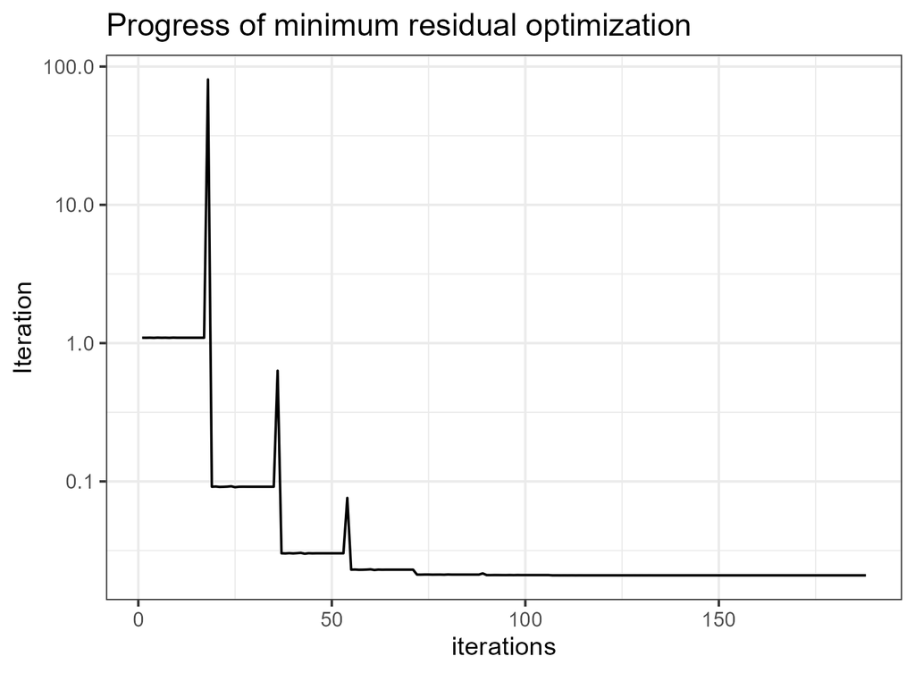

### Factor analysis: minimum residual method

```r
# Example of using R's optimizaton functions to get some factors "from scratch"
# in practice, you wouldn't need to do this! There are a lot of better functions
# for factor analysis. The goal here is just to see something where the process
# is a little less opaque.

loc<-url('https://github.com/Neilblund/SDSB340-Spring-2026/raw/refs/heads/master/Data/depression_scores.rds')
scores<-readRDS(loc)
vars<-c("DPQ010", "DPQ020", "DPQ040", "DPQ050")
scores_select<-scores[,vars]


# The function to calculate a sum of squared residuals for a set of parameters
# compared to an observed correlation matrix:

minres_obj <- function(params, R, n_var, n_fact) {
  # Reconstruct the Loading Matrix (A)
  A <- matrix(params, nrow = n_var, ncol = n_fact)
  # Calculate Reproduced Correlation Matrix (R_hat = A %*% A')
  R_hat <- A %*% t(A)
  # Calculate Residuals (Observed - Reproduced)
  Resid <- R - R_hat
  # Extract off-diagonal residuals only
  # MinRes ignores the diagonal
  diag(Resid) <- 0
  # Return Sum of Squared Residuals
  return(sum(Resid^2))
}

R <- cor(scores_select)    # the observed correlation matrix
n_var <- nrow(R)    # the number of variables
n_fact <- 1         # the number of assumed factors

# random starting values for the loadings
# Note, in practice, we would use some heuristics to ensure a plausible starting
# point
init_loadings <- runif(n_var * n_fact, 0, 0.1)

fit <- optim(
  par = init_loadings,
  fn = minres_obj,
  R = R,
  n_var = n_var,
  n_fact = n_fact,
  method = "BFGS",
  control = list(maxit = 5000)
)

# Formatting the results
loadings_matrix <- matrix(fit$par, nrow = n_var, ncol = n_fact)
rownames(loadings_matrix) <- rownames(R)
colnames(loadings_matrix) <- paste0("MR", 1:n_fact)
loadings_matrix
```

```
             MR1
DPQ010 0.7362362
DPQ020 0.8029317
DPQ040 0.5543354
DPQ050 0.5252447
```

### Factor analysis: loadings

Factor loadings correspond to the $b_i$ values for each item. So they represent the correlation between item $i$ and the latent variable.

- So, the correlation between item 1, “Having little interest in doing things”, and the latent variable is about $0.74$.

$$\text{Factor loadings} = \left(\begin{array}{c}0.74\\0.80\\0.55\\0.53\end{array}\right)$$

### Factor analysis: communality

Communality is the proportion of the variation in item $i$ that is explained by the latent factor(s). It can be calculated from summing the squared factor loadings.

- So variation in the latent factor accounts for about $0.73^2 = 0.54$ of the variation in answers to item 1

$$\text{Factor loadings} = \left(\begin{array}{c}0.74\\0.80\\0.55\\0.53\end{array}\right)$$

### Factor analysis: uniqueness

Uniqueness is the proportion of variation in item $i$ that is not explained by the latent factor(s). It can be calculated by taking 1 - the communality score.

- So $1 - 0.54 = 0.46$ of the variation in item 1 is explained by something other than depression (random error or something else)

$$\text{Factor loadings} = \left(\begin{array}{c}0.74\\0.80\\0.55\\0.53\end{array}\right)$$

### Factor analysis: variance explained

Proportion of total variance explained is the total variation across factors explained by the factor model. It can be calculated from sum of squared factor loadings divided by the number of items.

- So $\frac{074.^2 + 0.80^2 + 0.55^2 + 0.53^2}{4} = .45$ of the total variation in responses to these questions is explained by variance in depression.

$$\text{Factor loadings} = \left(\begin{array}{c}0.74\\0.80\\0.55\\0.53\end{array}\right)$$

### Adding dimensions

- What if we suspect there’s more than one latent variable that explains our data?
- In the worst case, we might have one latent dimension for every item in the index.
- More plausibly, we might have a few additional items, and we might think some of these are correlated with “sleep deprivation” in addition to being correlated with depression.

[figure not shown]

### Adding dimensions

The equations for generating each item now have an additional parameter that reflects the effect of sleep deprivation:

$$\begin{align}
X_{1} = \alpha_{1} + b_{11}f_{\text{depression}} +b_{21}f_{\text{sleep deprivation}} + e_{1}\\
X_{2} = \alpha_{2} + b_{12}f_{\text{depression}} +b_{22}f_{\text{sleep deprivation}} + e_{2}\\
X_{3} = \alpha_{3} + b_{13}f_{\text{depression}} +b_{23}f_{\text{sleep deprivation}} + e_{3}\\
X_{4} = \alpha_{4} + b_{14}f_{\text{depression}} +b_{24}f_{\text{sleep deprivation}} + e_{4}\\
X_{5} = \alpha_{5} + b_{15}f_{\text{depression}} +b_{25}f_{\text{sleep deprivation}} + e_{5}\\
X_{6} = \alpha_{6} + b_{16}f_{\text{depression}} +b_{26}f_{\text{sleep deprivation}} + e_{6}\\
\end{align}$$

Now we’re interested in estimating a matrix of factor loadings for each item on each dimension.

$$\mathbf{\beta} = \left(\begin{array}{cccc}b_{11}& b_{12}& \dots & b_{1m}\\b_{21} & b_{22} & \dots & b_{2m}\\ \vdots & \vdots & & \vdots \\b_{p1} & b_{p2} & \dots & b_{pm}\end{array}\right) = \text{matrix of factor loadings}$$

### Adding dimensions

Fortunately, this doesn’t change our basic assumptions or our goal. There’s a theoretical correlation/covariance matrix implied by our model. Our goal is to find a set of factor loadings that would probably have generated the data we see in the sample.

Adding dimensions does add a couple of additional complexities.

### Adding dimensions: rotation

- For problems with multiple factors, there are multiple sets of loadings that could give us equally good fits.
- This is referred to as rotational indeterminacy: factor loadings can be “rotated” without producing a different fit.
- Initial factor solutions are typically rotated to find a solution that is easily interpretable. Importantly, this relies on making some assumptions about the underlying structure of the factors you’re exploring.

### Adding dimensions: rotation

- Orthogonal rotations assume that the factors are not correlated with each other.
- Oblique rotations allow the factors to be correlated with each other.
- In most cases, an oblique rotation is more consistent with the data.

### Rotations

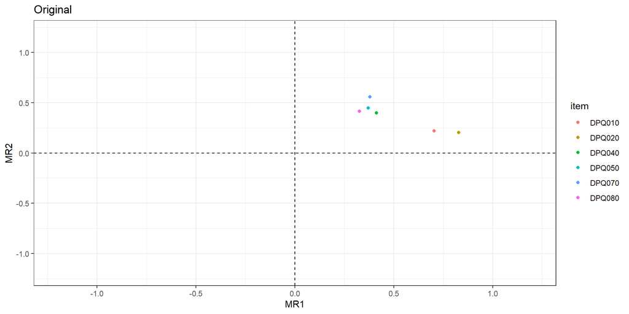

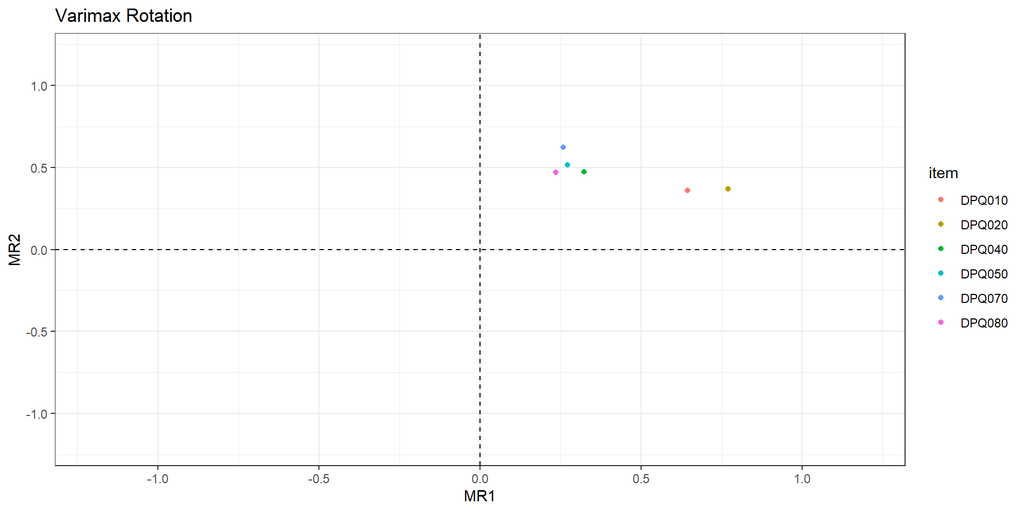

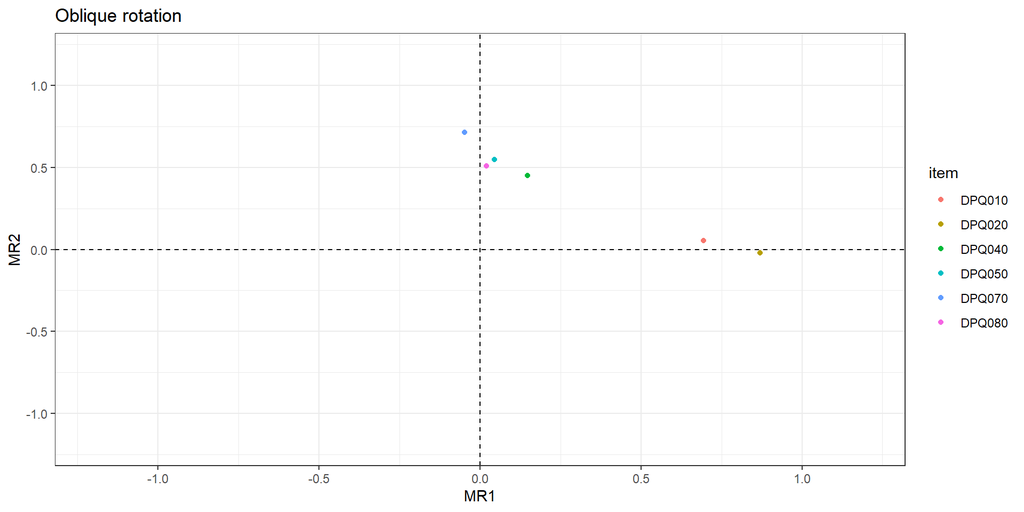

### Finding factor scores

```r
loc<-url('https://github.com/Neilblund/SDSB340-Spring-2026/raw/refs/heads/master/Data/depression_scores.rds')
scores<-readRDS(loc)
vars<-c("DPQ010", "DPQ020", "DPQ040", "DPQ050", "DPQ070",  "DPQ080" )
scores_select<-scores[,vars]


R <- cor(scores_select)    # the observed correlation matrix
n_var <- nrow(R)    # the number of variables
n_fact <- 2         # the number of assumed factors

# random starting values for the loadings
# Note, in practice, we would use some heuristics to ensure a plausible starting
# point
set.seed(3265)

init_loadings<-runif(n_var*n_fact, min = -.1, max=.1)

fit <- optim(
  par = init_loadings,
  fn = minres_obj,
  R = R,
  n_var = n_var,
  n_fact = n_fact,
  method = "BFGS",
  control = list(maxit = 5000)
)

# Formatting the results
loadings_matrix <- matrix(fit$par, nrow = n_var, ncol = n_fact)
rownames(loadings_matrix) <- rownames(R)
colnames(loadings_matrix) <- paste0("MR", 1:n_fact)
```

### Factor analysis: interpreting results

The loadings have the same interpretation, but each column represents a difference factor.

- So the correlation between item 1 and factor 1 is 0.70, and the correlation between this item and factor 2 is 0.22.

$$\text{Factor loadings} = \left(\begin{array}{c}
0.70&0.22\\
0.83&0.20\\
0.41&0.40\\
0.37&0.45 \\
0.38&0.56 \\
0.33&0.41 \\
\end{array}\right)$$

### Factor analysis: communality

Communality is the proportion of the variation in item $i$ that is explained by the latent factor(s). It can be calculated from summing the squared factor loadings.

- So the communality for item 1 is $0.70^2 + 0.22^2 = 0.54$. 54% of the variation in item 1 is explained by variation in factors 1 and 2.

$$\text{Factor loadings} = \left(\begin{array}{c}
0.70&0.22\\
0.83&0.20\\
0.41&0.40\\
0.37&0.45 \\
0.38&0.56 \\
0.33&0.41 \\
\end{array}\right)$$

### Factor analysis: uniqueness

Uniqueness is the proportion of variation in item $i$ that is not explained by the latent factor(s). It can be calculated by taking 1 - the communality score.

- So $1 - 0.54 = .46$ of the variation in item 1 is explained by something other than the two latent factors

$$\text{Factor loadings} = \left(\begin{array}{c}
0.70&0.22\\
0.83&0.20\\
0.41&0.40\\
0.37&0.45 \\
0.38&0.56 \\
0.33&0.41 \\
\end{array}\right)$$

### Factor analysis: variance explained

Proportion of total variance explained is the total variation across factors explained by the factor model. It can be calculated from sum of squared factor loadings divided by the number of items.

$$\text{Factor loadings} = \left(\begin{array}{c}
0.70&0.22\\
0.83&0.20\\
0.41&0.40\\
0.37&0.45 \\
0.38&0.56 \\
0.33&0.41 \\
\end{array}\right)$$

### Factor analysis: variance explained

- Rotating the factors will change the values for individual items, but it preserves their relative distances from each other.
- Rotating the factors won’t change the overall “fit”, so the total explained variance should be the same.

### Factor analysis: the number of factors

So how many factors do we have in this data? Would fit improve even more if we used 3 factors?

### Factor analysis: the number of factors

One way to get a sense of the optimal number of factors is to use a scree plot.

- The y-axis represents an eigenvalue, which represents the variance explained by each factor. Higher values mean more variance explained.
- The x-axis shows the number of factors
- The advice is typically to retain factors before the “elbow” where we see diminishing returns in explained variance.

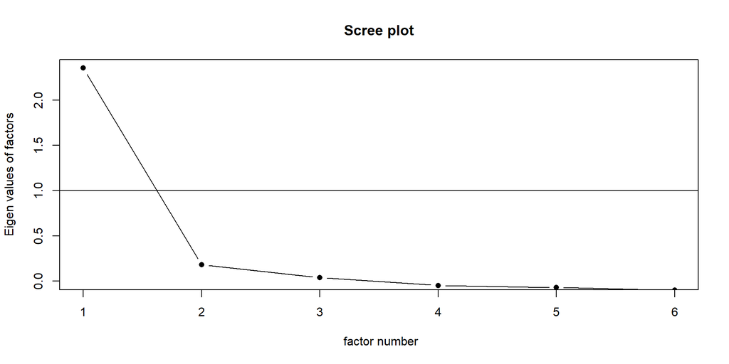

### Factor analysis: the number of factors

In this case, we seem to see pretty significant diminishing returns after just one factor.

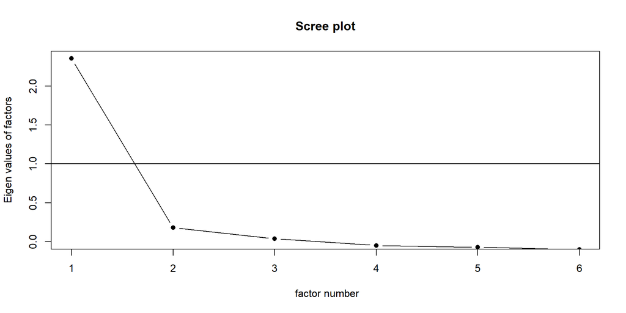